# Cross-Validation and Reliable Performance Estimation

## Recap

In the previous notebook, we saw that adding flexibility to a model improves its ability to approximate complex relationships. Additional flexibility also increases the model’s ability to fit the training data – that is, more flexible models will generally have lower training error than less flexible models. Because training error continues to drop with additional flexibility, we need an additional data source which was unseen by the model during the training process in order to provide an unbiased estimate of future model performance. Ideally, this test error will decrease until the optimal level of model flexibility is reached but then the test error will increase once the model becomes *overfit* to the training data.

At the end of the last notebook, we drew an *elbow plot*, showing how the *training* and *test errors* changed as model flexibility was increased. This visual technique allowed us to identify which models were likely *underfit* and what the threshold for an *overfit* model was. We can use these elbow plots in general, to identify an appropriate level of flexibility for our models.

## Motivation

We’ve placed a lot of faith in our *training* and *test* sets over the last few weeks. We’ve given the training data total power to determine our model coefficients and the test data sole power to determine our expected performance metrics (R-Squared, RMSE, etc.). Perhaps we should have some concern here – especially given our most recent discussion about model flexibility and its relationship to *variance*. Different training data would result in differently estimated coefficients and different testing data would result in differently estimated performance estimates – do we really want to believe that our random data splitting resulted in perfectly fair and representative training and test data? It is certainly possible that we, by chance, would generate a particularly “easy” training set and a particularly “difficult” test set (or vice-versa). Furthermore, if we are in the business of constructing models often, such an occurrence is guaranteed eventually!

To highlight how much influence our training and test sets can have on our models and the expectations we develop about them, each plot below corresponds to the RMSE for models of degree $1$, $2$, $3$, and $5$ for a single data set but using a different training/testing splits. To produce the plots below, I’ve generated a toy dataset and am constructing/analyzing the performance of a variety of models (linear, quadratic, cubic, fifth-degree) for 10 different training/test set combinations below. Interpret the elbow plots to see how the estimated performance metrics change for each different training and test set.

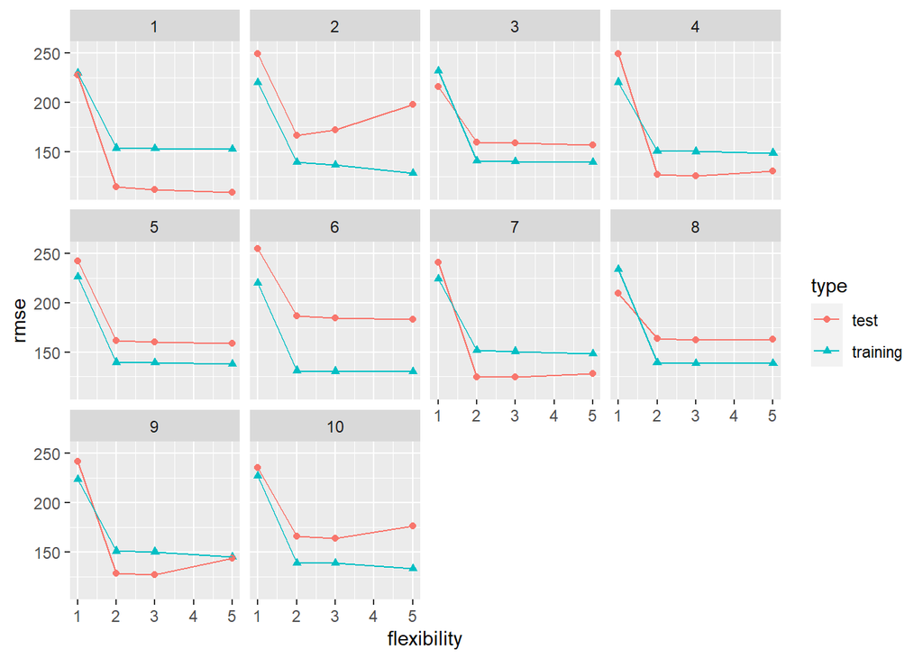

| flexibility | trial | type | rsq | rmse |
| --- | --- | --- | --- | --- |
| 2 | 1 | test | 0.6593570 | 114.7737 |
| 2 | 2 | test | 0.7253872 | 166.9643 |
| 2 | 3 | test | 0.6374607 | 160.0023 |
| 2 | 4 | test | 0.8284092 | 127.3285 |
| 2 | 5 | test | 0.4600495 | 161.7844 |
| 2 | 6 | test | 0.6501866 | 186.2976 |
| 2 | 7 | test | 0.8038373 | 124.2833 |
| 2 | 8 | test | 0.6308369 | 163.7026 |
| 2 | 9 | test | 0.8273417 | 128.1685 |
| 2 | 10 | test | 0.6708070 | 165.8269 |

The elbow plots pretty reliably identify the appropriate level of model flexibility. In the toy data set I generated, the true association between $x$ and $y$ was quadratic. However, the *test RMSE*, which we utilize in estimating the “accuracy” of our model’s predictions fluctuates quite wildly – between a low of below $115$ for the first training/test set combination, and a high of nearly $190$ for the sixth training/test combination. There is a big difference between claiming our model’s predictions are accurate to within $\pm 230$ units and within $\pm 380$ units. These discrepancies should be worrisome. We are putting lots of trust in our models, so it would be nice to have more certainty about our estimated coefficients, predictions, and error/performance estimates.

## Objectives

The discussions above have highlighted that, while we thought we were doing the right things with our training and test set approach all along, we were actually very vulnerable to the random data that – by chance – fell into our training set and our test set. Different splits can lead to different models and certainly different model performance expectations. In this notebook, we’ll develop a robust framework which will help us obtain more reliable performance estimates *and* help us estimate how uncertain we are in those estimates.

After working through this notebook you should be able to:

- Describe the pitfalls associated with the *validation set approach* we’ve been using up to this point in our course.
- Describe how *cross-validation* works as well as how it mitigates the issues associated with a single validation set.
- Implement *cross-validation* using `vfold_cv()` in conjunction with `fit_resamples()` from `tidymodels` to fit and assess models using cross-validation.
- Observe and interpret individual performance metrics on each cross-validation *fold* as well as to aggregate those metrics to a more stable performance estimate along with an estimate for our uncertainty in this metric.

## Cross-Validation

In cross-validation, rather thank breaking our data set into a single training and test set, we’ll break our data into $k$ folds, were $k$ is somewhere between $3$ and $n$ (your total number of observations). Each of the folds will take one turn playing the role of the *test* set for a model fit on all of the other folds – that is, with cross-validation, we’ll fit $k$ models and get $k$ performance estimates. Once we have those performance estimates, they can be averaged and we can compute the standard error corresponding to the performance metric. This provides us (i) more stable and reliable model performance estimates, and (ii) a way to quantify the uncertainty associated with those metrics.

The most commonly utilized number of folds are $5$ and $10$. In the special case where you utilize $n$ folds, each observation belongs to its own fold – this is often called *Leave-One-Out Cross-Validation* – it is very computationally expensive. The greater the number of folds, the more models need to be fit.

### Implementing Cross-Validation in `tidymodels`

We’ll update our workflow as follows:

1. Split data into training and validation sets using `initial_split()`, `training()`, and `testing()` as usual, but with a larger proportion of data belonging to the “training” set. We’ll use `prop = 0.9` for the penguins data – this will leave about $34$ penguins in our holdout set.
- We’ll reserve this smaller *test* set as a final sanity check for our model before we push it to production.
2. We’ll use `vfold_cv()` to split the *training* data into *cross-validation folds*.
3. We’ll build our model(s) as usual (create a model specification, build a recipe, package the model and recipe into a workflow) and then use `fit_resamples()` rather than `fit()` to fit and assess our model on our cross-validation folds.
4. Once we’ve fit our models on the folds (the resamples), we’ll collect the performance metrics on them using `collect_metrics()`.

```r
penguins_split <- initial_split(penguins, prop = 0.9)
penguins_train <- training(penguins_split)
penguins_test <- testing(penguins_split)

penguins_folds <- vfold_cv(penguins_train)

lr_spec <- linear_reg() %>%
  set_engine("lm")

lr_rec <- recipe(body_mass_g ~ ., data = penguins_train) %>%
  step_dummy(species) %>%
  step_dummy(island) %>%
  step_interact(~ starts_with("species"):contains("length")) %>%
  step_interact(~ bill_length_mm:bill_depth_mm)

lr_wf <- workflow() %>%
  add_model(lr_spec) %>%
  add_recipe(lr_rec)

lr_results <- lr_wf %>%
  fit_resamples(penguins_folds)
```

Now that we’ve fit our model, we can extract the results from Cross-Validation. There are two types of result we can get back – individual results from each fold:

```r
lr_results %>%
  collect_metrics(summarize = FALSE) %>%
  pivot_wider(id_cols = id, names_from = .metric, values_from = .estimate) %>%
  kable() %>%
  kable_styling(bootstrap_options = c("hover", "striped"))
```

| id | rmse | rsq |
| --- | --- | --- |
| Fold01 | 362.4834 | 0.7540292 |
| Fold02 | 274.2758 | 0.8794673 |
| Fold03 | 302.1292 | 0.7981302 |
| Fold04 | 334.4922 | 0.7574754 |
| Fold05 | 242.2274 | 0.9157606 |
| Fold06 | 261.8536 | 0.9053921 |
| Fold07 | 312.0557 | 0.9015039 |
| Fold08 | 296.0174 | 0.8761237 |
| Fold09 | 241.9070 | 0.9119503 |
| Fold10 | 248.9867 | 0.9231618 |

or a single set of metrics summarized across all of the folds:

```r
lr_results %>%
  collect_metrics() %>%
  kable() %>%
  kable_styling(bootstrap_options = c("hover", "striped"))
```

| .metric | .estimator | mean | n | std_err | .config |
| --- | --- | --- | --- | --- | --- |
| rmse | standard | 287.6428273 | 10 | 12.980473 | Preprocessor1_Model1 |
| rsq | standard | 0.8622995 | 10 | 0.021012 | Preprocessor1_Model1 |

Seeing the results on the individual folds gives us an idea about how our performance metrics fluctuate from one set to the next. Are the performance metrics relatively stable or do they vary wildly from one fold to the next? Seeing the aggregated results gives us a more trustworthy estimate for each of our performance metrics and also reports a standard error for each metric. That standard error measures the average fluctuation in the performance estimate from one fold to the next.

In summary, we can be confident that the R-Squared value for this model is around $86.2\% \pm 4\%$. Similarly, we can be confident that the predictions our model makes will be accurate to within about $\pm 2\left(287.64 \pm 2\cdot 12.98\right)$ grams. Check with the other students in the class – we should all have similar estimates for the Cross-Validation RMSE, even when we don’t set a seed. This was not the case when we used the *validation-set approach*.

## Summary

In this notebook we saw that different test sets result in different model performance estimates. In fact, those model performance estimates can vary quite wildly from one choice of test set to another. For this reason, we’ve developed the notion of *cross-validation*, a powerful tool for producing stable and more reliable performance estimates than what we get from the *validation-set approach* alone.

In *cross-validation*, our training data is split into several folds. Each fold takes one turn being left out of model training and serves as the validation set for a model fit on the remaining folds. In doing this, we obtain several model performance estimates which can be averaged to obtain a more stable performance estimate along with an estimate for the standard error of that performance estimate.

- To split our training data into cross-validation folds, we use `vfold_cv()`
- To fit our data using cross-validation we use `fit_resamples()` in place of the `fit()` function we have been using up to this point.
- We obtain cross-validation performance metrics by calling `collect_metrics()` on our “fitted” model.

Cross-validation is a very powerful tool and we’ll continue to use it in a variety of ways throughout the remainder of our course.